# Spatially explicit models for distance sampling data

Practical “solution” 5: Prediction and variance

David L Miller

## Aims

By the end of this practical, you should feel comfortable:

- Making a prediction using the `predict()` function
- Summing the prediction cells to obtain a total abundance for a given area
- Plotting a map of predictions
- Knowing when to use `dsm.var.prop` and when to use `dsm.var.gam`
- Estimating variance for a given prediction area
- Estimating variance per-cell for a prediction grid
- Interpreting the `summary()` output for uncertainty estimates
- Making maps of the coefficient of variation in R

## Loading the packages and data

```r
library(knitr)
library(dsm)
```

```r
library(ggplot2)
library(patchwork)
```

Load our models and data:

```r
load("spermwhale.RData")
# load models
load("dsms.RData")
load("dsms-checked.RData")
# rename one model
dsm_nb_xy_ms <- dsm_nb_xy_ms_p1_4
```

## Prediction data

Our prediction data lives in the `predgrid` object. This data was prepared from various sources and the since some of the covariates were dynamic (SST, NPP and EKE), the dates for these were arbitrarily chosen as 2 June 2004, or Julian date 153.

If you’re preparing this data yourself, the [`rerddap` package](https://cran.r-project.org/web/packages/rerddap/) can be used to obtain marine data from NOAA for both segments and predictions.

We can take a look at our data using `head()` to see the first few rows:

```r
head(predgrid)
```

```
##            x      y      Depth      SST      NPP DistToCAS          EKE off.set
## 126 547984.6 788254  153.59825 12.04609 1462.521 11788.974 0.0008329031   1e+08
## 127 557984.6 788254  552.31067 12.81379 1465.410  5697.248 0.0009806611   1e+08
## 258 527984.6 778254   96.81992 12.90251 1429.432 13722.626 0.0011575423   1e+08
## 259 537984.6 778254  138.23763 13.21393 1424.862  9720.671 0.0013417297   1e+08
## 260 547984.6 778254  505.14386 13.75655 1379.351  8018.690 0.0026881567   1e+08
## 261 557984.6 778254 1317.59521 14.42525 1348.544  3775.462 0.0045683752   1e+08
##          long      lat
## 126 -66.52252 40.94697
## 127 -66.40464 40.94121
## 258 -66.76551 40.86781
## 259 -66.64772 40.86227
## 260 -66.52996 40.85662
## 261 -66.41221 40.85087
```

As we saw in the slides, the `predict()` function will fill in the variables in the model formula with these values to obtain the predictions at each cell.

For example using the model `dsm_nb_xy_ms`:

```r
pp <- predict(dsm_nb_xy_ms, predgrid, off.set=predgrid$off.set)
```

This is just a list of numbers – the predicted abundance per cell. We can sum these to get the estimated abundance for the study area:

```r
sum(pp, na.rm=TRUE)
```

```
## [1] 1580.121
```

We can also plot this to get a spatial representation of the predictions:

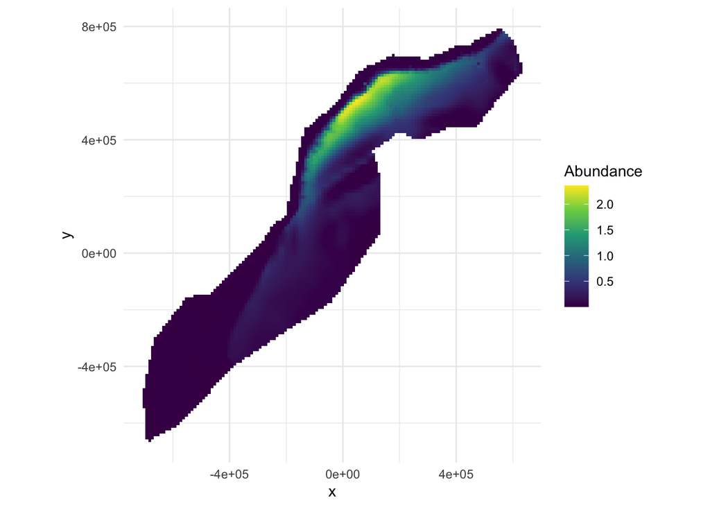

Predicted surface for abundance estimates with bivariate spatial smooth along with environmental covariates.

```r
# assign the predictions to the prediction grid data.frame
predgrid$Nhat_nb_xy <- pp

# plot!
p <- ggplot(predgrid) +
  geom_tile(aes(x=x, y=y, fill=Nhat_nb_xy, width=10*1000, height=10*1000)) +
  coord_equal() +
  # better colour scheme
  scale_fill_viridis_c() +
  # cleaner plot
  theme_minimal() +
  # set the label for the fill colour
  labs(fill="Abundance")
print(p)
```

Use the chunks above as a template and make predictions for the other models you saved in the previous exercises. In particular, compare the models with only spatial terms to those with environmental covariates included.

**Making predictions**

Let’s try making predictions with a few models. Let’s compare two count models (negative binomial and Tweedie) an two estimated abundance models (negative binomial and Tweedie).

I’ll make the plots then use the `patchwork` package to add together plots and put them together at the end.

First the Tweedie count, with a smooth of space.

```r
predgrid$Nhat_tw_xy <- predict(dsm_tw_xy_ms, predgrid,
                               off.set=predgrid$off.set)

# plot
p_tw_xy <- ggplot(predgrid) +
  geom_tile(aes(x=x, y=y, fill=Nhat_tw_xy,
                width=10*1000, height=10*1000)) +
  coord_equal() +
  scale_fill_viridis_c() +
  theme_minimal() +
  ggtitle("dsm_tw_xy_ms") +
  labs(fill="Abundance")
```

Now make a plot for the negative binomial habitat count model:

```r
predgrid$Nhat_nb_noxy <- predict(dsm_nb_noxy_ms_refit,
                                 predgrid,
                                 off.set=predgrid$off.set)

# plot
p_nb_noxy <- ggplot(predgrid) +
  geom_tile(aes(x=x, y=y, fill=Nhat_nb_noxy,
                width=10*1000, height=10*1000)) +
  coord_equal() +
  scale_fill_viridis_c() +
  theme_minimal() +
  ggtitle("dsm_nb_noxy_ms_refit") +
  labs(fill="Abundance")
```

Now the estimated abundance, with negative binomial response:

```r
predgrid$Nhat_nb_ae <- predict(dsm_nb_xy_ms_ae, predgrid,
                               off.set=predgrid$off.set)

# plot
p_nb_ae <- ggplot(predgrid) +
  geom_tile(aes(x=x, y=y, fill=Nhat_nb_ae,
                width=10*1000, height=10*1000)) +
  coord_equal() +
  scale_fill_viridis_c() +
  theme_minimal() +
  ggtitle("dsm_nb_xy_ms_ae") +
  labs(fill="Abundance")
```

Finally estimated abundance, with Tweedie response:

```r
predgrid$Nhat_tw_ae <- predict(dsm_tw_xy_ms_ae, predgrid,
                               off.set=predgrid$off.set)

# plot
p_tw_ae <- ggplot(predgrid) +
  geom_tile(aes(x=x, y=y, fill=Nhat_tw_ae,
                width=10*1000, height=10*1000)) +
  coord_equal() +
  scale_fill_viridis_c() +
  theme_minimal() +
  ggtitle("dsm_tw_xy_ms_ae") +
  labs(fill="Abundance")
```

Now plotting these all together:

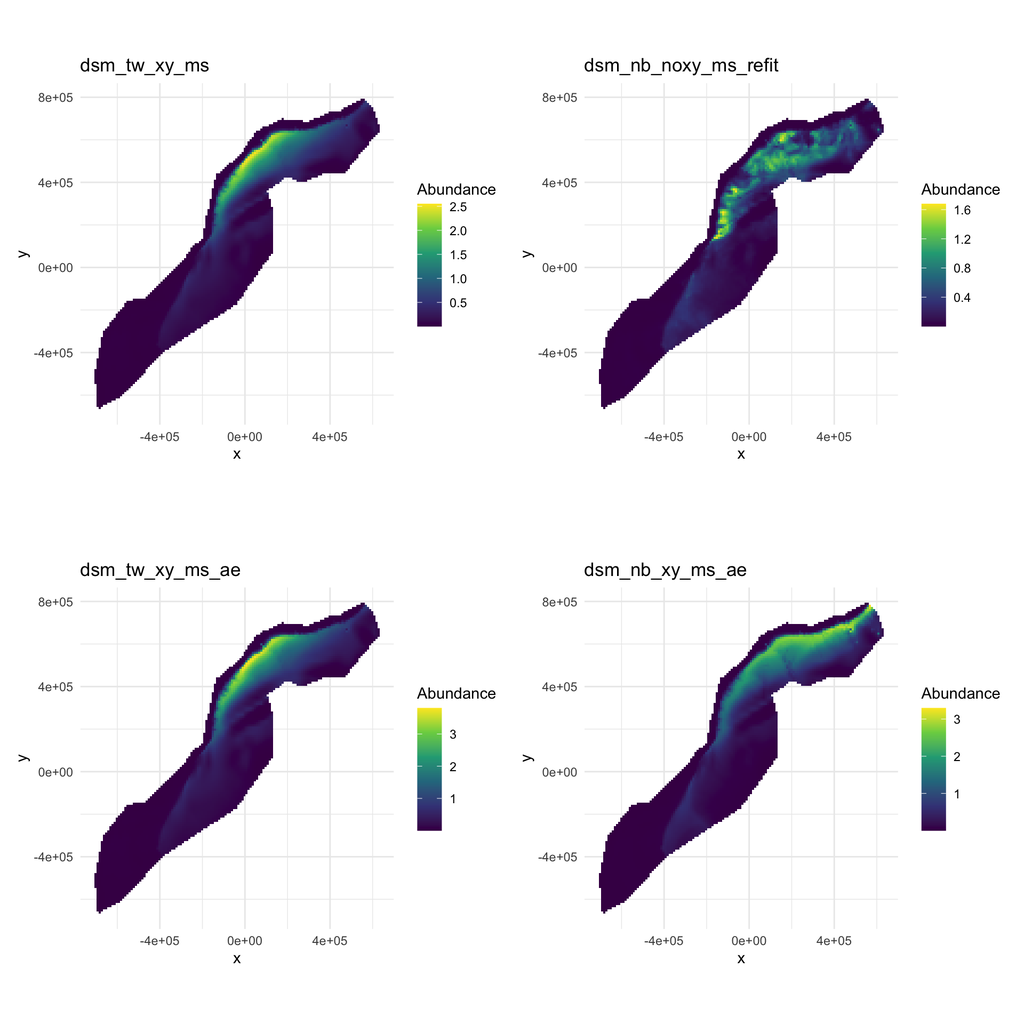

```r
(p_tw_xy + p_nb_noxy)/(p_tw_ae + p_nb_ae)
```

We can see a similar pattern generally in all the plots with high values at the shelf edge, though we can see that `dsm_nb_noxy_ms_refit` has much more fine detail in it than the other models.

Now make some abundance estimates:

```r
sum(predgrid$Nhat_tw_xy)
```

```
## [1] 1595.535
```

```r
sum(predgrid$Nhat_nb_noxy)
```

```
## [1] 1198.791
```

```r
sum(predgrid$Nhat_tw_ae)
```

```
## [1] 2373.881
```

```r
sum(predgrid$Nhat_nb_ae)
```

```
## [1] 2402.684
```

We do see a big difference here between the estimated abundance models and the count models. Bear in mind that the count models were both fitted just using the half-normal detection function.

```r
load("df-models.RData")

# need to build the binned Beaufort covariate as was
# in the detection function
segs$BeaufortCut <- cut(segs$Beaufort, seq(0, 5, by=1),
                        include.lowest=TRUE,
                        ordered.result=TRUE)

# do a quick model selection, based off previous results
dsm_nb_xy_ms_refit <- dsm(count~s(x,y, bs="ts", k=60) +
                             s(Depth, bs="ts", k=20) +
                             #s(DistToCAS, bs="ts") + # 1
                             #s(SST, bs="ts") + # 2
                             s(EKE, bs="ts", k=20),# +
                             #s(NPP, bs="ts"), # 3
                      df_hr_beau, segs, obs,
                      family=nb())
summary(dsm_nb_xy_ms_refit)
```

```
##
## Family: Negative Binomial(0.114)
## Link function: log
##
## Formula:
## count ~ s(x, y, bs = "ts", k = 60) + s(Depth, bs = "ts", k = 20) +
##     s(EKE, bs = "ts", k = 20) + offset(off.set)
##
## Parametric coefficients:
##             Estimate Std. Error z value Pr(>|z|)
## (Intercept) -20.4266     0.2262  -90.31   <2e-16 ***
## ---
## Signif. codes:  0 '***' 0.001 '**' 0.01 '*' 0.05 '.' 0.1 ' ' 1
##
## Approximate significance of smooth terms:
##             edf Ref.df Chi.sq  p-value
## s(x,y)   1.8750     59 19.804 2.29e-05 ***
## s(Depth) 3.4571     19 48.197  < 2e-16 ***
## s(EKE)   0.8012     19  3.473   0.0365 *
## ---
## Signif. codes:  0 '***' 0.001 '**' 0.01 '*' 0.05 '.' 0.1 ' ' 1
##
## R-sq.(adj) =  0.089   Deviance explained = 38.9%
## -REML = 380.46  Scale est. = 1         n = 949
```

Plotting that resulting model:

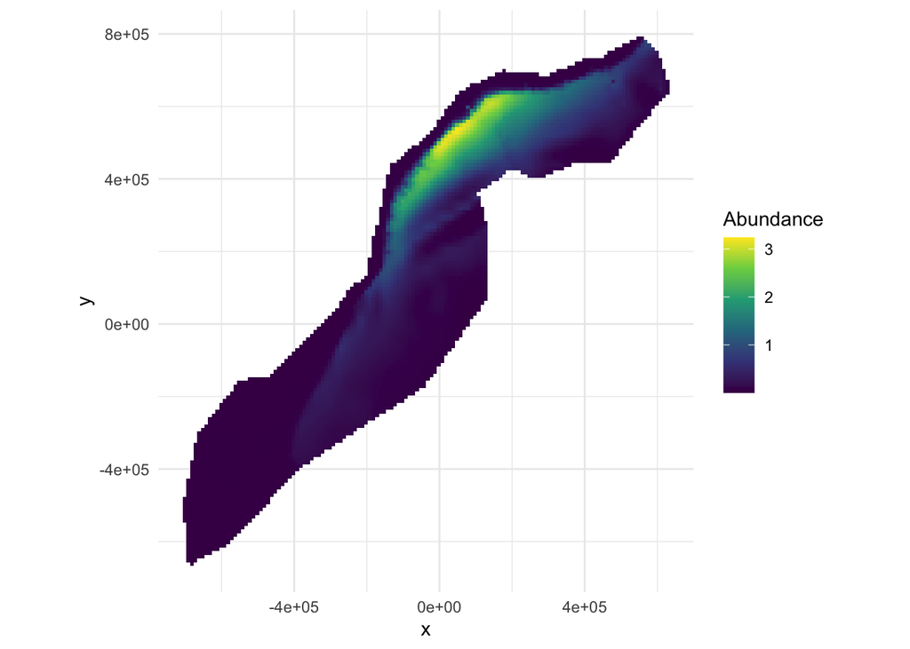

```r
predgrid$Nhat_nb_xy <- predict(dsm_nb_xy_ms_refit,
                               predgrid,
                               off.set=predgrid$off.set)

# plot
p_nb_xy <- ggplot(predgrid) +
  geom_tile(aes(x=x, y=y, fill=Nhat_nb_xy,
                width=10*1000, height=10*1000)) +
  coord_equal() +
  scale_fill_viridis_c() +
  theme_minimal() +
  labs(fill="Abundance")
print(p_nb_xy)
```

Now we get something more like the estimated abundance models, so we can see that including sea state can have a really big effect!

```r
sum(predgrid$Nhat_nb_xy)
```

```
## [1] 2206.73
```

And let’s do the same thing for the Tweedie:

```r
# do a quick model selection, based off previous results
dsm_tw_xy_ms_refit <- dsm(count~s(x,y, bs="ts", k=60) +
                             s(Depth, bs="ts", k=20) +
                             #s(DistToCAS, bs="ts", k=20) + # 1
                             s(SST, bs="ts", k=20),# +
                             #s(EKE, bs="ts", k=20),# +
                             #s(NPP, bs="ts", k=20), # 2
                      df_hr_beau, segs, obs,
                      family=tw())
summary(dsm_tw_xy_ms_refit)
```

```
##
## Family: Tweedie(p=1.254)
## Link function: log
##
## Formula:
## count ~ s(x, y, bs = "ts", k = 60) + s(Depth, bs = "ts", k = 20) +
##     s(SST, bs = "ts", k = 20) + offset(off.set)
##
## Parametric coefficients:
##             Estimate Std. Error t value Pr(>|t|)
## (Intercept)  -20.572      0.248  -82.94   <2e-16 ***
## ---
## Signif. codes:  0 '***' 0.001 '**' 0.01 '*' 0.05 '.' 0.1 ' ' 1
##
## Approximate significance of smooth terms:
##            edf Ref.df     F  p-value
## s(x,y)   1.761     59 0.191   0.0014 **
## s(Depth) 3.851     19 2.301  < 2e-16 ***
## s(SST)   5.566     19 1.400 2.91e-05 ***
## ---
## Signif. codes:  0 '***' 0.001 '**' 0.01 '*' 0.05 '.' 0.1 ' ' 1
##
## R-sq.(adj) =  0.221   Deviance explained = 40.9%
## -REML = 381.55  Scale est. = 4.0286    n = 949
```

So now with SST in the model, let’s see what that looks like:

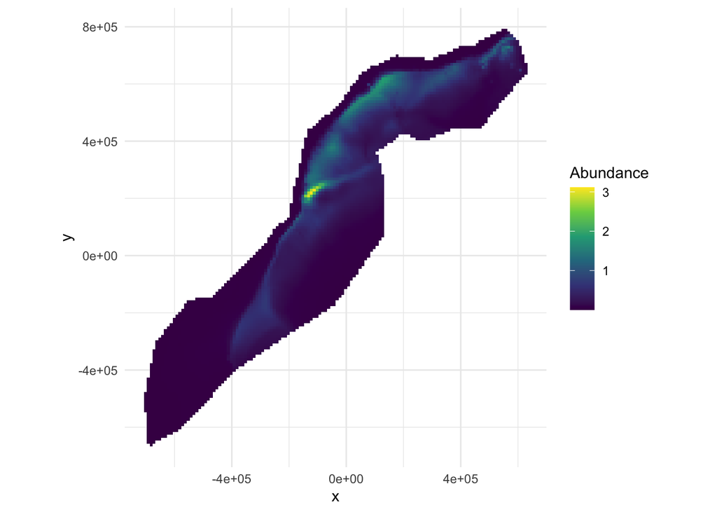

```r
predgrid$Nhat_tw_xy <- predict(dsm_tw_xy_ms_refit,
                               predgrid,
                               off.set=predgrid$off.set)

# plot
p_tw_xy <- ggplot(predgrid) +
  geom_tile(aes(x=x, y=y, fill=Nhat_tw_xy,
                width=10*1000, height=10*1000)) +
  coord_equal() +
  scale_fill_viridis_c() +
  theme_minimal() +
  labs(fill="Abundance")
print(p_tw_xy)
```

```r
sum(predgrid$Nhat_tw_xy)
```

```
## [1] 1461.226
```

However, let’s remember that this was not our favoured model previously and remains so: the quantile-quantile plot shows the negative binomial model has a better fit:

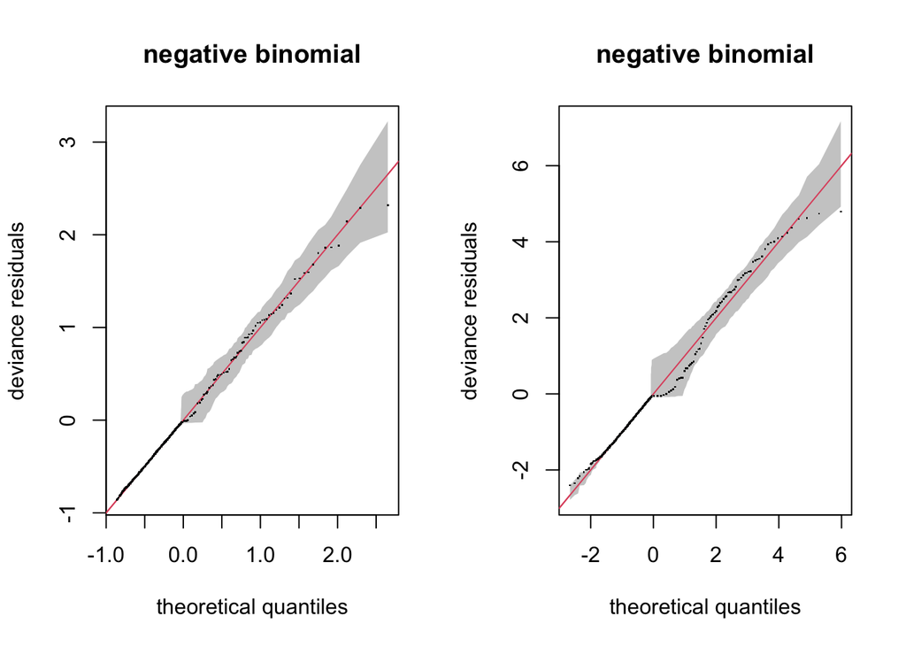

```r
par(mfrow=c(1,2))
qq.gam(dsm_nb_xy_ms_refit, rep=200, main="negative binomial")
qq.gam(dsm_tw_xy_ms_refit, rep=200, main="negative binomial")
```

So we won’t pursue this model (`dsm_tw_xy_ms_refit`) further.

## Variance estimation

Depending on the covariates in the model, we can use either `dsm.var.prop` or `dsm.var.gam`. Remember: - `dsm.var.gam` - assumes spatial model and detection function are independent - `dsm.var.prop` - propagates uncertainty from detection function to spatial model - only works for `count` models - covariates can only vary at segment level

If there are no covariates in the detection function, use `dsm.var.gam` since there’s no covariance between the detection function and the spatial model.

`dsm_nb_xy_ms` doesn’t include any covariates at the observer level in the detection function, so we can use `dsm.var.gam` to estimate the uncertainty.

```r
# now estimate variance
var_nb_xy_ms <- dsm.var.gam(dsm_nb_xy_ms, predgrid,
                             off.set=predgrid$off.set)
```

To summarise the results of this variance estimate:

```r
summary(var_nb_xy_ms)
```

```
## Summary of uncertainty in a density surface model calculated
##  analytically for GAM, with delta method
##
## Approximate asymptotic confidence interval:
##     2.5%     Mean    97.5%
## 1111.871 1580.121 2245.569
## (Using log-Normal approximation)
##
## Point estimate                 : 1580.121
## CV of detection function       : 0.06670757
## CV from GAM                    : 0.168
## Total standard error           : 285.6377
## Total coefficient of variation : 0.1808
```

Try this out for some of the other models you’ve saved.

**Variance estimation**

We can use either the delta method (`dsm.var.gam`) or variance propagation (`dsm.var.prop`) with our count model:

```r
dsm_nb_vargam <- dsm.var.gam(dsm_nb_xy_ms_refit, predgrid,
                             off.set=predgrid$off.set)
summary(dsm_nb_vargam)
```

```
## Summary of uncertainty in a density surface model calculated
##  analytically for GAM, with delta method
##
## Approximate asymptotic confidence interval:
##     2.5%     Mean    97.5%
## 1234.617 2206.730 3944.263
## (Using log-Normal approximation)
##
## Point estimate                 : 2206.73
## CV of detection function       : 0.2503225
## CV from GAM                    : 0.1706
## Total standard error           : 668.4868
## Total coefficient of variation : 0.3029
```

```r
dsm_nb_varprop <- dsm.var.prop(dsm_nb_xy_ms_refit, predgrid,
                             off.set=predgrid$off.set)
summary(dsm_nb_varprop)
```

```
## Summary of uncertainty in a density surface model calculated
##  by variance propagation.
##
## Probability of detection in fitted model and variance model
##   BeaufortCut Fitted.model Fitted.model.se Refitted.model
## 4       [0,1]   0.78346539      0.32022998     0.51500357
## 3       (1,2]   0.36995577      0.08459385     0.54063974
## 1       (2,3]   0.70626890      0.09957053     0.64889155
## 2       (3,4]   0.28615108      0.08823118     0.26889664
## 5       (4,5]   0.04465498      0.03348484     0.05885038
##
## Approximate asymptotic confidence interval:
##     2.5%     Mean    97.5%
## 1301.437 1944.461 2905.193
## (Using log-Normal approximation)
##
## Point estimate                 : 1944.461
## Standard error                 : 402.5554
## Coefficient of variation       : 0.207
```

Looking at these summaries we see that we actually get a reduction in the CV for our predictions! This is due to negative covariance between the spatial and detection parts of the model.

The table at the top of the `dsm.var.prop` output lets us check whether anything went wrong during the variance estimation. Values in the `Refitted.model` column should be no more than twice `Fitted.model.se` away from their corresponding `Fitted.model` values.

For the estimated abundance models, we must use `dsm.var.gam`:

```r
dsm_nb_vargam_ae <- dsm.var.gam(dsm_nb_xy_ms_ae, predgrid,
                             off.set=predgrid$off.set)
summary(dsm_nb_vargam_ae)
```

```
## Summary of uncertainty in a density surface model calculated
##  analytically for GAM, with delta method
##
## Approximate asymptotic confidence interval:
##     2.5%     Mean    97.5%
## 1328.487 2402.684 4345.464
## (Using log-Normal approximation)
##
## Point estimate                 : 2402.684
## CV of detection function       : 0.2081943
## CV from GAM                    : 0.2288
## Total standard error           : 743.3098
## Total coefficient of variation : 0.3094
```

```r
dsm_tw_vargam_ae <- dsm.var.gam(dsm_tw_xy_ms_ae, predgrid,
                             off.set=predgrid$off.set)
summary(dsm_tw_vargam_ae)
```

```
## Summary of uncertainty in a density surface model calculated
##  analytically for GAM, with delta method
##
## Approximate asymptotic confidence interval:
##     2.5%     Mean    97.5%
## 1484.918 2373.881 3795.032
## (Using log-Normal approximation)
##
## Point estimate                 : 2373.881
## CV of detection function       : 0.2081943
## CV from GAM                    : 0.125
## Total standard error           : 576.4863
## Total coefficient of variation : 0.2428
```

Again the Tweedie model here is just for example, we didn’t prefer this model based on quantile-quantile plots.

## Plotting

We can plot a map of the coefficient of variation, but we first need to estimate the variance per prediction cell, rather than over the whole area.

```r
# use the split function to make each row of the predictiond data.frame into
# an element of a list
predgrid$height <- predgrid$width <- 10*1000
predgrid_var_split <- split(predgrid, 1:nrow(predgrid))
var_split_nb_xy_ms <- dsm.var.gam(dsm_nb_xy_ms, predgrid_var_split,
                                   off.set=predgrid$off.set)
```

Now we have the per-cell coefficients of variation, we assign that to a column of the prediction grid data and plot it as usual:

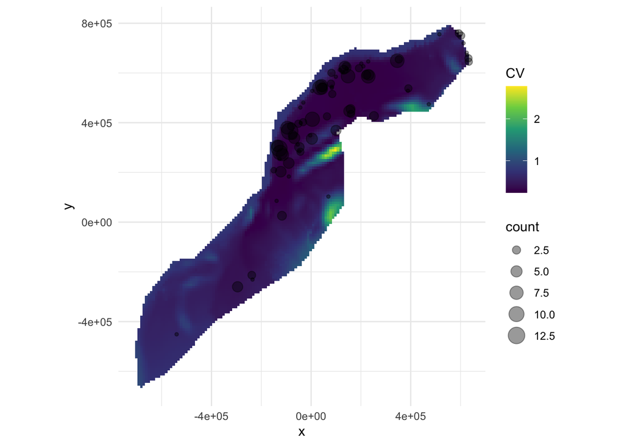

Uncertainty (CV) in prediction surface from bivariate spatial smooth with environmental covariates. Sightings overlaid.

```r
cv <- sqrt(var_split_nb_xy_ms$pred.var)/unlist(var_split_nb_xy_ms$pred)
predgrid$CV <- cv
p <- ggplot(predgrid) +
  geom_tile(aes(x=x, y=y, fill=CV, width=10*1000, height=10*1000)) +
  scale_fill_viridis_c() +
  coord_equal() +
  geom_point(aes(x=x,y=y, size=count), alpha=0.4,
             data=dsm_nb_xy_ms$data[dsm_nb_xy_ms$data$count>0,]) +
  theme_minimal()
print(p)
```

Note that here we overplot the segments where sperm whales were observed (and scale the size of the point according to the number observed), using `geom_point()`. The `alpha=` argument makes the points semi-transparent.

Try this with the other models you fitted and see what the differences are between the maps of coefficient of variation.

Try plotting the effort over a CV plot, using the data in the model.

**Plotting uncertainty**

Let’s make plots to compare the maps using the delta method and variance propagation for the count model `dsm_nb_xy_ms_refit`:

```r
# vargam plot
dsm_nb_vargam_plot <- dsm.var.gam(dsm_nb_xy_ms_refit, predgrid_var_split,
                             off.set=predgrid$off.set)
# can use plot=FALSE to get the ggplot object that we can modify
pl_vg <- plot(dsm_nb_vargam_plot, plot=FALSE, observations=FALSE)
# modify plot
pl_vg <- pl_vg +
  geom_point(aes(x=x, y=y), data=dsm_nb_noxy_ms_refit$data,
             colour="lightgrey", alpha=.5, size=0.2) +
  theme(legend.position="bottom") +
  scale_fill_viridis_c()
# varprop plot
dsm_nb_varprop_plot <- dsm.var.prop(dsm_nb_xy_ms_refit, predgrid_var_split,
                             off.set=predgrid$off.set)
pl_vp <- plot(dsm_nb_varprop_plot, plot=FALSE, observations=FALSE)
pl_vp <- pl_vp +
  geom_point(aes(x=x, y=y), data=dsm_nb_noxy_ms_refit$data,
             colour="lightgrey", alpha=.5, size=0.2) +
  theme(legend.position="bottom") +
  scale_fill_viridis_c()
```

Putting that together in a plot:

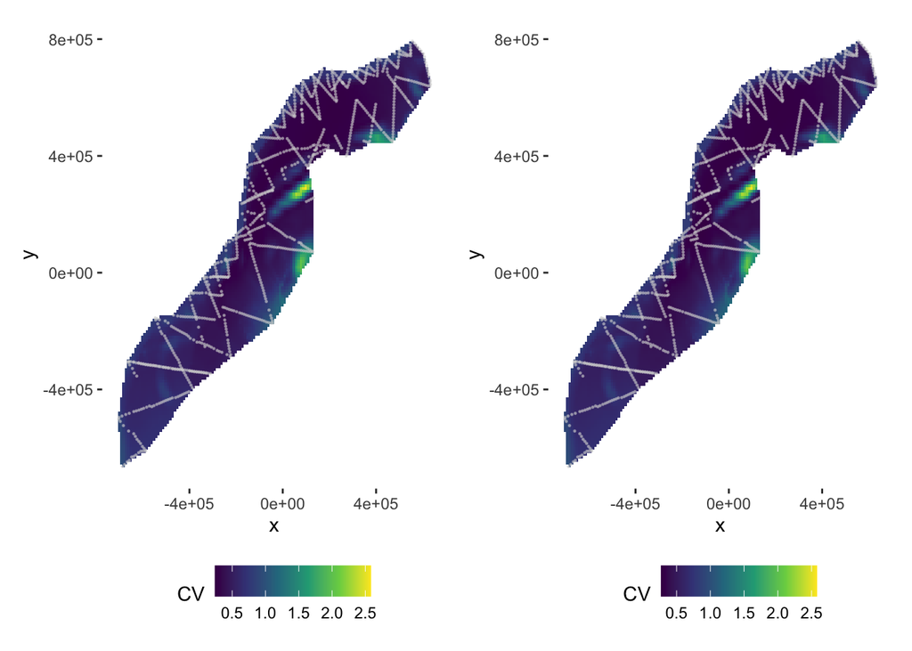

```r
pl_vg + pl_vp
```

We can see some differences here in the spatial pattern of the ucnertainty as well as the overall size we see in the `summary` difference above.

**One more thing…**

What about using an interaction of EKE and Depth? I’ll try this just for the count model with negative binomial response.

We can construct this using a *tensor product* which takes two (or more) univariate smooths and create a 2 (or more) dimensional smooth. We can set `k` for each dimension (we can even set different basis functions in each direction) but note that it’s the term will use the product of these `k`s number of parameters (`k=c(10,10)` leads to a 100 parameter term!). The tensor product includes the univariate terms (it’s a full interaction), so we need to remove them from the model:

```r
dsm_nb_te <- dsm(count~s(x,y, bs="ts", k=30) +
                       #s(DistToCAS, bs="ts") + # 1
                       #s(SST, bs="ts") + # 3
                       te(EKE, Depth, bs="ts", k=c(10, 10)),# +
                       #s(NPP, bs="ts"), # 2
                      df_hr_beau, segs, obs,
                      family=nb())
summary(dsm_nb_te)
```

```
##
## Family: Negative Binomial(0.117)
## Link function: log
##
## Formula:
## count ~ s(x, y, bs = "ts", k = 30) + te(EKE, Depth, bs = "ts",
##     k = c(10, 10)) + offset(off.set)
##
## Parametric coefficients:
##             Estimate Std. Error z value Pr(>|z|)
## (Intercept)  -20.551      0.273  -75.27   <2e-16 ***
## ---
## Signif. codes:  0 '***' 0.001 '**' 0.01 '*' 0.05 '.' 0.1 ' ' 1
##
## Approximate significance of smooth terms:
##                 edf Ref.df Chi.sq  p-value
## s(x,y)        1.865     29  15.66  0.00017 ***
## te(EKE,Depth) 6.153     87  53.05 6.63e-06 ***
## ---
## Signif. codes:  0 '***' 0.001 '**' 0.01 '*' 0.05 '.' 0.1 ' ' 1
##
## R-sq.(adj) =  0.0954   Deviance explained = 40.6%
## -REML = 380.29  Scale est. = 1         n = 949
```

We can plot this just like any other model:

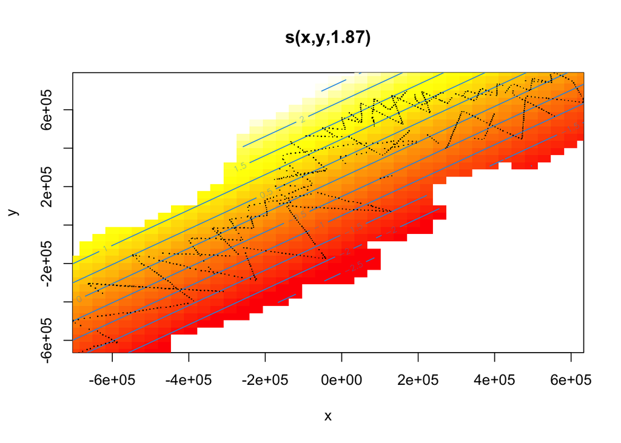

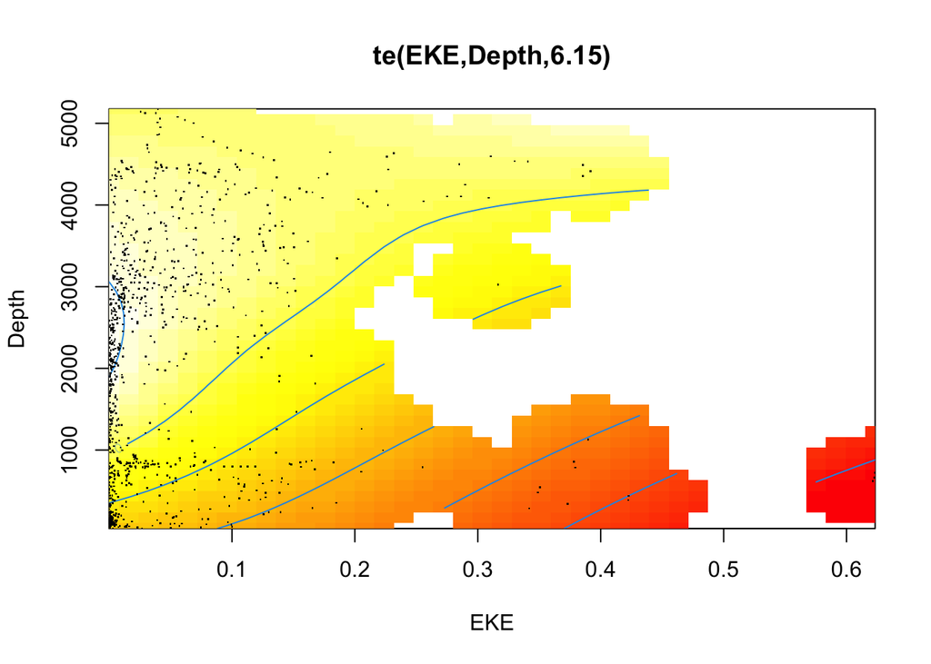

```r
plot(dsm_nb_te, scheme=2, shade=TRUE)
```

A useful test here of whether we need the tensor would be using the `ti` form of the tensor. This allows us to look at the parts of the interaction on their own. We can write a tensor product `te(x, y)` as `ti(x) + ti(y) + ti(x, y)`, so we get the main effects and interactions separately in the model `summary` table. Doing that:

```r
dsm_nb_ti <- dsm(count~s(x,y, bs="ts", k=30) +
                       #s(DistToCAS, bs="ts") +
                       #s(SST, bs="ts") +
                       ti(EKE, bs="ts", k=10) +
                       ti(Depth, bs="ts", k=10) +
                       ti(EKE, Depth, bs="ts", k=c(10, 10)),# +
                       #s(NPP, bs="ts"),
                      df_hr_beau, segs, obs,
                      family=nb())
summary(dsm_nb_ti)
```

```
##
## Family: Negative Binomial(0.115)
## Link function: log
##
## Formula:
## count ~ s(x, y, bs = "ts", k = 30) + ti(EKE, bs = "ts", k = 10) +
##     ti(Depth, bs = "ts", k = 10) + ti(EKE, Depth, bs = "ts",
##     k = c(10, 10)) + offset(off.set)
##
## Parametric coefficients:
##             Estimate Std. Error z value Pr(>|z|)
## (Intercept) -20.4445     0.2281  -89.62   <2e-16 ***
## ---
## Signif. codes:  0 '***' 0.001 '**' 0.01 '*' 0.05 '.' 0.1 ' ' 1
##
## Approximate significance of smooth terms:
##                    edf Ref.df Chi.sq  p-value
## s(x,y)        1.880157     29 19.094 3.23e-05 ***
## ti(EKE)       1.606484      9  6.188    0.020 *
## ti(Depth)     3.302363      9 49.849  < 2e-16 ***
## ti(EKE,Depth) 0.000435     70  0.000    0.872
## ---
## Signif. codes:  0 '***' 0.001 '**' 0.01 '*' 0.05 '.' 0.1 ' ' 1
##
## R-sq.(adj) =  0.0831   Deviance explained = 39.5%
## -REML =  376.6  Scale est. = 1         n = 949
```

We can see that the interaction term `ti(EKE, Depth)` has a very small EDF and isn’t significant at the 0.05 level. So I think this one isn’t a go-er unfortunately, even if the biological/oceanographic story is more compelling.